#### Group Members: Yusuf Hassan Haji; Ev Rousev; Konstatinos Pananas

##### Declaration: We declare that , the entire assignment was done by all the three members

# Question: Do countries with low initial levels of capital grow faster than and catch up with countries that start off with high levels of capital?

## Motivation

In this simulation we are trying to identify how fast a country will converge to a steady state equilibrium k*, depending on the initial level of investment and savings. The motivation for this simulation is the “Absolute convergence hypothesis”: In the neoclassical model of exogenous growth, the economy tends to grow faster for a low level of initial capital-labor ratio compared to the case of a higher capita-labor ratio. This could be otherwise stated as when countries have similar characteristics, the ‘poor’ countries with low initial income y0, will display a higher growth rate and the two variables are expected to be negatively correlated. Assumptions of the Basic Solow Model

## Method

The Solow model takes the rates of savings, population growth and technological progress as exogenous. A Cobb-Douglas production function is assumed , so production at time t is given by;

$Y(t) = K(t)^Î± (A(t)L(t))^{1-Î±} ,0<Î±<1$

The Solow growth model is a neoclassical growth model where the amount of capital stock per capita k_t evolves according to the rule:

$k_(t+1)=(szk_(t+1)+(1-Î´)k_t)/(1+n)$

Whereby:

- s is an exogenously given savings rate
- z is a productivity parameter
- Î± is capitalâ€™s share of income
- n is the population growth rate
- Î´ is the depreciation rate

  The steady state of the Solow model is the k that solves equation(1) when

  $k_(t+1)=k_t=k$

L and A are assumed to be exogenous at rates n and gâˆ¶ $L(t) = L(0) e^{nt}$

$A(t)= A(0) e^{gt}$

Defining variables in intensive form: y â‰¡ Y/AL , k â‰¡ K/AL

Therefore ;

$y = K^Î± (AL)^{1-Î±} = k^Î± = (K/AL)^{Î±}$

$y = k^Î±$

Capital accumulates and the evolution of capital is governed by:

$k Ì‡(t) = sy(t)- (n+Î´)k(t)$

$= k Ì‡(t) = sy(t)- (n+Î´)k(t)$

In steady state k Ì‡=0 and so;

And so the steady state capital per effective worker is :

But the central-predictions of the Solow model concern the impact of saving and population growth on real income and so we can derive the steady state output per effective worker : y Since :  
y = k^Î± And so : $y^ = (s/(Î´+n+g))^{âˆ/(1-âˆ)}$

And by taking the log of $lny^*$

So we have the steady-state income per capita as:

$((Y(t))/(L(t)))^*=A(t).y^*=A_0 e^gt (s/(Î´+n+g))^{âˆ/(1-âˆ)}$ $lny(t)=lny^* + e^{-Î»t} [ lny(0)-lny^*]…………………………………(E.1)$ Where y â‰¡ Y/AL is the output per effective worker

Since y^* is the steady state level of income per effective worker and ; y(t) is the actual value of output per effective worker at time t. Convergence in the Solow model is arrived at by taking a first order Taylor expansion of output around the steady state level gives :

$(d[lny(t)-lny^*])/dt=-Î»[lny(t)-lny^*]$

The Solow model suggests a natural regression to study the rate of convergence;

$lny(t)= (1-e^{-Î»t} ) lny^*+ e^{-Î»t} lny(0)$

$lny(t)- lny(0) = lny^*- (e^{-Î»t} ) lny^*+ e^{-Î»t} lny(0) - lny(0)$

$lny(t)- lny(0) = (1-e^{-Î»t} ) lny^*+ e^{-Î»t} lny(0) - lny(0)$

$lny(t)- lny(0)= (1-e^{-Î»t} ) lny^* - (1-e^{-Î»t} ) lny(0)$

The above can also be derived as above by subtracting lny(t-T) from both sides. T is an arbitrary log in order to get income per effective worker at some initial year.

Equation can therefore become;

$lny(t)- lny(t-T) = lny^* - (e^{-Î»t} ) lny^*- lny(t-T)+ e^(-Î»t) lny(t-T)$

$lny(t)- lny(t-T)=(1-e^{-Î»t} ) lny^* - (1-e^{-Î»t}) lny(t-T)$

and T is a lag of one year. It can be written as above by multiplying both sides by capital letter T and it cancels out and we remain with :

$(lny(t)- lny(t-T))/T=((1-e^{-Î»t} ) lny^* )/T* T- ((1-e^{-Î»t} ) lny(t-T))/T * T$

$lny(t)- lny(t-T) = (1-e^{-Î»t} ) lny^* - (1-e^{-Î»t} ) lny(t-T)$

In this regard, we consider a time span of just one year which is technically feasible given that the underlying dataset provides annual data. The left hand side shows what convergence of income per capita depends on and provides a model. Thus the growth of income is a function of the determinants of ultimate steady state and the initial level of income . The coefficient in front of lagged income which is $- (1-e^{-Î»t})$ is the coefficient of the initial level of income. This coefficient is used to determine whether there is a significant tendency towards convergence. Since the Solow model makes quantitative predictions about the speed of convergence to steady state and requiring that $yâ‰ˆy^*$ to hold close in a steady state , we find that this would require the following value of $Î»âˆ¶ Î» = (1-Î±)(Î´+n+g)$ Therefore , the parameter governing the speed of convergence is $Î»$ .

$k_(t+1)=(szk_(t+1)+(1-Î´)k_t)/(1+n)$

```python
"""
Filename: solow.py
Reference: http://quant-econ.net/py/python_oop.html
"""
from __future__ import division
import numpy as np

class Solow:
    r"""
    Implements the Solow growth model with update rule

    .. math::
        k_{t+1} = \frac{s z k^{\alpha}_t}{1 + n}  + k_t \frac{1 + d}{1 + n}

    """

    def __init__(self, n, s, d, alpha, z, k):
        """
        The Solow model with Cobb-Douglas production function.
        """
        self.n, self.s, self.d, self.alpha, self.z = n, s, d, alpha, z
        self.k = k


    def h(self,x):

        temp = self.s * self.z * self.k**self.alpha + self.k * (1 - self.d)
        return temp / (1 + self.n)

    def update(self):

        self.k =  self.h(self.k)

    def steady_state(self):

         return ((self.s * self.z) / (self.n + self.d))**(1 / (1 - self.alpha))

    def generate_sequence(self, t):

        path = []
        for i in range(t):
            path.append(self.k)
            self.update()
        return path
```

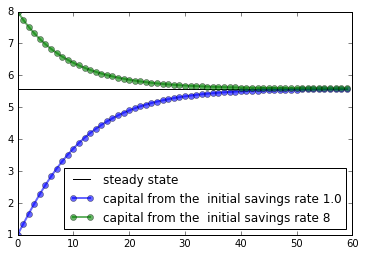

```python
import matplotlib.pyplot as plt
baseline_params = 0.05, 0.25, 0.1, 0.3, 2.0, 1.0
s1 = Solow(*baseline_params)
s2 = Solow(*baseline_params)
s2.k = 8 # This is for the high economy
T = 60
fig, ax = plt.subplots()
# We plot the common steady-state level of capital
ax.plot([s1.steady_state()]*T, 'k-', label='steady state')

for s in s1, s2:
    lb = 'capital from the  initial savings rate {}'.format(s.k)
    ax.plot(s.generate_sequence(T), 'o-', lw=2, alpha=0.6, label=lb)

ax.legend(loc='lower right')
plt.show()
```

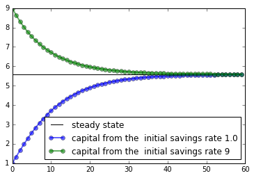

```python
import matplotlib.pyplot as plt
baseline_params = 0.05, 0.25, 0.1, 0.3, 2.0, 1.0
s1 = Solow(*baseline_params)
s2 = Solow(*baseline_params)
s2.k = 9 # This is for the high economy
T = 60
fig, ax = plt.subplots()
# We plot the common steady-state level of capital
ax.plot([s1.steady_state()]*T, 'k-', label='steady state')

for s in s1, s2:
    lb = 'capital from the  initial savings rate {}'.format(s.k)
    ax.plot(s.generate_sequence(T), 'o-', lw=2, alpha=0.6, label=lb)

ax.legend(loc='lower right')
plt.show()
```

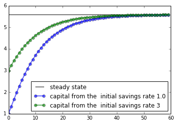

```python
import matplotlib.pyplot as plt
baseline_params = 0.05, 0.25, 0.1, 0.3, 2.0, 1.0
s1 = Solow(*baseline_params)
s2 = Solow(*baseline_params)
s2.k = 3 # This is for the high economy
T = 60
fig, ax = plt.subplots()
# We plot the common steady-state level of capital
ax.plot([s1.steady_state()]*T, 'k-', label='steady state')

for s in s1, s2:
    lb = 'capital from the  initial savings rate {}'.format(s.k)
    ax.plot(s.generate_sequence(T), 'o-', lw=2, alpha=0.6, label=lb)

ax.legend(loc='lower right')
plt.show()
```

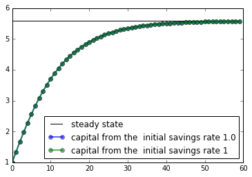

```python
import matplotlib.pyplot as plt
baseline_params = 0.05, 0.25, 0.1, 0.3, 2.0, 1.0
s1 = Solow(*baseline_params)
s2 = Solow(*baseline_params)
s2.k = 1 # This is for the high economy
T = 60
fig, ax = plt.subplots()
# We plot the common steady-state level of capital
ax.plot([s1.steady_state()]*T, 'k-', label='steady state')

for s in s1, s2:
    lb = 'capital from the  initial savings rate {}'.format(s.k)
    ax.plot(s.generate_sequence(T), 'o-', lw=2, alpha=0.6, label=lb)

ax.legend(loc='lower right')
plt.show()
```

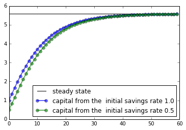

```python
import matplotlib.pyplot as plt
baseline_params = 0.05, 0.25, 0.1, 0.3, 2.0, 1.0
s1 = Solow(*baseline_params)
s2 = Solow(*baseline_params)
s2.k = 0.5 # This is for the high economy
T = 60
fig, ax = plt.subplots()
# We plot the common steady-state level of capital
ax.plot([s1.steady_state()]*T, 'k-', label='steady state')

for s in s1, s2:
    lb = 'capital from the  initial savings rate {}'.format(s.k)
    ax.plot(s.generate_sequence(T), 'o-', lw=2, alpha=0.6, label=lb)

ax.legend(loc='lower right')
plt.show()
```

## Conclusion

The Solow model allows economists to view capital accumulation and the technological progress overtone in a framework which is easy to track. If a country is not present in the environment of Ak, then no technological progress would exist according to the model The model illustrates steady state levels output and capital within the parameters. When savings rates increase, the steady state output increased, causing the economy to grow into a new steady state. When this point is reached growth will decline and eventually stop. Therefore the Solow model illustrates that a factor, witch an increase over time, causes the growth. An increase in technology or population growth are one of these factors. Capital accumulation is determined by the savings rate, population growth and the rate of depreciation. Output growth, per capita is exogenously determined by technological progress.

When applied to the targeted county in the real world, a number of things are bound to happen. One if these events takes place if growth due to capital accumulation occurs, growth would be very strong when countries first accumulate capital. This growth will eventually slow down as shown similar in our graphs. This applied to for example Asian countries in the 50’s and 60’s. Counties like these also converge in output per capita. This will lead counties like these to catch up to developed countries where all countries have reached a steady state, assuming the production function is similar. However these assumptions do not always hold as there are exemptions in the model as seen throughout history. Less developed Asian countries are actually seen to fall behind developing countries, unlike the model’s prediction which suggests that they will catch up. Another example can be found in the Sovjet Union under Josef Stalin. Compared to the United States, the Sovjet Union had higher saving due to its lower level of capital. This would suggest that the Sovjet Union would catch up, according to the model. It did not. These event might be explained by other factors such as productivity increase, but it illustrates the limitations of the Solow model.